# data_process

2조

2021 5 10

#라이브러리

```r
#데이터 탐색
#install.packages("tidyverse")
library(tidyverse)
```

```r
library(dplyr)
library(ggplot2)
```

데이터 탐색에 필요한 라이브러리 입니다.

#데이터 수집

```r
train <- read.csv("./data/train.csv", stringsAsFactors=F)
test <- read.csv("./data/test.csv", stringsAsFactors=F)
#df<- read.csv("./open/sample_submission.csv", stringsAsFactors=F)
```

#데이터 탐색

(reference: https://rpubs.com/kdmid/ch05_Exploratory_Data_Analysis)

```r
glimpse(train) #str과 기능비슷
```

```
## Rows: 26,457
## Columns: 20
## $ index         <int> 0, 1, 2, 3, 4, 5, 6, 7, 8, 9, 10, 11, 12, 13, 14, 15, 16~
## $ gender        <chr> "F", "F", "M", "F", "F", "F", "F", "M", "M", "F", "F", "~
## $ car           <chr> "N", "N", "Y", "N", "Y", "N", "N", "N", "Y", "N", "N", "~
## $ reality       <chr> "N", "Y", "Y", "Y", "Y", "Y", "N", "Y", "Y", "Y", "Y", "~
## $ child_num     <int> 0, 1, 0, 0, 0, 2, 0, 0, 1, 0, 0, 1, 1, 0, 0, 2, 0, 0, 0,~
## $ income_total  <dbl> 202500, 247500, 450000, 202500, 157500, 270000, 315000, ~
## $ income_type   <chr> "Commercial associate", "Commercial associate", "Working~
## $ edu_type      <chr> "Higher education", "Secondary / secondary special", "Hi~
## $ family_type   <chr> "Married", "Civil marriage", "Married", "Married", "Marr~
## $ house_type    <chr> "Municipal apartment", "House / apartment", "House / apa~
## $ DAYS_BIRTH    <int> -13899, -11380, -19087, -15088, -15037, -13413, -17570, ~
## $ DAYS_EMPLOYED <int> -4709, -1540, -4434, -2092, -2105, -4996, -1978, -5420, ~
## $ FLAG_MOBIL    <int> 1, 1, 1, 1, 1, 1, 1, 1, 1, 1, 1, 1, 1, 1, 1, 1, 1, 1, 1,~
## $ work_phone    <int> 0, 0, 0, 0, 0, 0, 0, 0, 0, 0, 1, 0, 0, 0, 0, 0, 0, 0, 0,~
## $ phone         <int> 0, 0, 1, 1, 0, 0, 0, 0, 0, 0, 1, 0, 0, 1, 1, 1, 1, 0, 0,~
## $ email         <int> 0, 1, 0, 0, 0, 1, 1, 1, 1, 0, 1, 0, 0, 0, 0, 0, 0, 1, 0,~
## $ occyp_type    <chr> "", "Laborers", "Managers", "Sales staff", "Managers", "~
## $ family_size   <dbl> 2, 3, 2, 2, 2, 4, 1, 2, 3, 2, 1, 3, 3, 2, 1, 4, 2, 2, 2,~
## $ begin_month   <dbl> -6, -5, -22, -37, -26, -18, -41, -53, -38, -5, -40, -51,~
## $ credit        <dbl> 1, 1, 2, 0, 2, 1, 2, 0, 2, 2, 2, 2, 0, 2, 2, 0, 1, 2, 2,~
```

```r
# $ FLAG_MOBIL    <int> 1, 1, 1, 1, 1, 1, 1, 1, 1, 1, 1, 1, 1, 1, 1, 1, 1, 1, 1, 1, 1, 1, 1, 1,~
# $ work_phone    <int> 0, 0, 0, 0, 0, 0, 0, 0, 0, 0, 1, 0, 0, 0, 0, 0, 0, 0, 0, 0, 0, 0, 0, 1,~
# $ phone         <int> 0, 0, 1, 1, 0, 0, 0, 0, 0, 0, 1, 0, 0, 1, 1, 1, 1, 0, 0, 0, 1, 1, 0, 1,~
# $ email         <int> 0, 1, 0, 0, 0, 1, 1, 1, 1, 0, 1, 0, 0, 0, 0, 0, 0, 1, 0, 0, 0, 0, 0, 1,~

summary(train)
```

```
##      index          gender              car              reality
##  Min.   :    0   Length:26457       Length:26457       Length:26457
##  1st Qu.: 6614   Class :character   Class :character   Class :character
##  Median :13228   Mode  :character   Mode  :character   Mode  :character
##  Mean   :13228
##  3rd Qu.:19842
##  Max.   :26456
##    child_num        income_total     income_type          edu_type
##  Min.   : 0.0000   Min.   :  27000   Length:26457       Length:26457
##  1st Qu.: 0.0000   1st Qu.: 121500   Class :character   Class :character
##  Median : 0.0000   Median : 157500   Mode  :character   Mode  :character
##  Mean   : 0.4287   Mean   : 187307
##  3rd Qu.: 1.0000   3rd Qu.: 225000
##  Max.   :19.0000   Max.   :1575000
##  family_type         house_type          DAYS_BIRTH     DAYS_EMPLOYED
##  Length:26457       Length:26457       Min.   :-25152   Min.   :-15713
##  Class :character   Class :character   1st Qu.:-19431   1st Qu.: -3153
##  Mode  :character   Mode  :character   Median :-15547   Median : -1539
##                                        Mean   :-15958   Mean   : 59069
##                                        3rd Qu.:-12446   3rd Qu.:  -407
##                                        Max.   : -7705   Max.   :365243
##    FLAG_MOBIL   work_phone         phone            email
##  Min.   :1    Min.   :0.0000   Min.   :0.0000   Min.   :0.00000
##  1st Qu.:1    1st Qu.:0.0000   1st Qu.:0.0000   1st Qu.:0.00000
##  Median :1    Median :0.0000   Median :0.0000   Median :0.00000
##  Mean   :1    Mean   :0.2247   Mean   :0.2943   Mean   :0.09128
##  3rd Qu.:1    3rd Qu.:0.0000   3rd Qu.:1.0000   3rd Qu.:0.00000
##  Max.   :1    Max.   :1.0000   Max.   :1.0000   Max.   :1.00000
##   occyp_type         family_size      begin_month         credit
##  Length:26457       Min.   : 1.000   Min.   :-60.00   Min.   :0.00
##  Class :character   1st Qu.: 2.000   1st Qu.:-39.00   1st Qu.:1.00
##  Mode  :character   Median : 2.000   Median :-24.00   Median :2.00
##                     Mean   : 2.197   Mean   :-26.12   Mean   :1.52
##                     3rd Qu.: 3.000   3rd Qu.:-12.00   3rd Qu.:2.00
##                     Max.   :20.000   Max.   :  0.00   Max.   :2.00
```

```r
# FLAG_MOBIL   work_phone         phone
# Min.   :1    Min.   :0.0000   Min.   :0.0000
# 1st Qu.:1    1st Qu.:0.0000   1st Qu.:0.0000
# Median :1    Median :0.0000   Median :0.0000
# Mean   :1    Mean   :0.2247   Mean   :0.2943
# 3rd Qu.:1    3rd Qu.:0.0000   3rd Qu.:1.0000
# Max.   :1    Max.   :1.0000   Max.   :1.0000
#
# email
# Min.   :0.00000
# 1st Qu.:0.00000
# Median :0.00000
# Mean   :0.09128
# Max.   :1.00000

str(train)
```

```
## 'data.frame':    26457 obs. of  20 variables:
##  $ index        : int  0 1 2 3 4 5 6 7 8 9 ...
##  $ gender       : chr  "F" "F" "M" "F" ...
##  $ car          : chr  "N" "N" "Y" "N" ...
##  $ reality      : chr  "N" "Y" "Y" "Y" ...
##  $ child_num    : int  0 1 0 0 0 2 0 0 1 0 ...
##  $ income_total : num  202500 247500 450000 202500 157500 ...
##  $ income_type  : chr  "Commercial associate" "Commercial associate" "Working" "Commercial associate" ...
##  $ edu_type     : chr  "Higher education" "Secondary / secondary special" "Higher education" "Secondary / secondary special" ...
##  $ family_type  : chr  "Married" "Civil marriage" "Married" "Married" ...
##  $ house_type   : chr  "Municipal apartment" "House / apartment" "House / apartment" "House / apartment" ...
##  $ DAYS_BIRTH   : int  -13899 -11380 -19087 -15088 -15037 -13413 -17570 -14896 -15131 -15785 ...
##  $ DAYS_EMPLOYED: int  -4709 -1540 -4434 -2092 -2105 -4996 -1978 -5420 -1466 -1308 ...
##  $ FLAG_MOBIL   : int  1 1 1 1 1 1 1 1 1 1 ...
##  $ work_phone   : int  0 0 0 0 0 0 0 0 0 0 ...
##  $ phone        : int  0 0 1 1 0 0 0 0 0 0 ...
##  $ email        : int  0 1 0 0 0 1 1 1 1 0 ...
##  $ occyp_type   : chr  "" "Laborers" "Managers" "Sales staff" ...
##  $ family_size  : num  2 3 2 2 2 4 1 2 3 2 ...
##  $ begin_month  : num  -6 -5 -22 -37 -26 -18 -41 -53 -38 -5 ...
##  $ credit       : num  1 1 2 0 2 1 2 0 2 2 ...
```

```r
# $ FLAG_MOBIL   : int  1 1 1 1 1 1 1 1 1 1 ... 핸드폰 소유 여부
# $ work_phone   : int  0 0 0 0 0 0 0 0 0 0 ... 업무용 전화 소유 여부
# $ phone        : int  0 0 1 1 0 0 0 0 0 0 ... 가정용 전화 소유 여부
# $ email        : int  0 1 0 0 0 1 1 1 1 0 ... 이메일 소유 여부
```

train 데이터는 총 20개의 변수와 26457개의 행이 존재합니다. test 데이터는 총 19개의 변수와 10000개의 행이 존재합니다. credit 변수는 종속변수로써 train 데이터에만 속해 있습니다.

##타입변환, 범주형 > 명목형(nominal)

```r
train$FLAG_MOBIL <- as.factor(train$FLAG_MOBIL)
train$work_phone <- as.factor(train$work_phone)
train$phone <- as.factor(train$phone)
train$email <- as.factor(train$email)
```

FLAG_MOBIL, work_phone, phone, email 네 개의 변수 모두 소유 여부에 대한 것이므로 범주형(명목형) 변수에 속합니다. 따라서 int로 설정되어 있는 타입을 factor로 변환해줍니다.

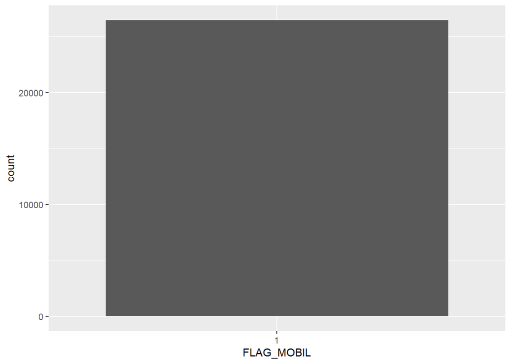

```r
#1) FLAG_MOBIL
ggplot(data=train)+
  geom_bar(mapping=aes(x=FLAG_MOBIL))
```

```r
train %>% count(FLAG_MOBIL)
```

```
##   FLAG_MOBIL     n
## 1          1 26457
```

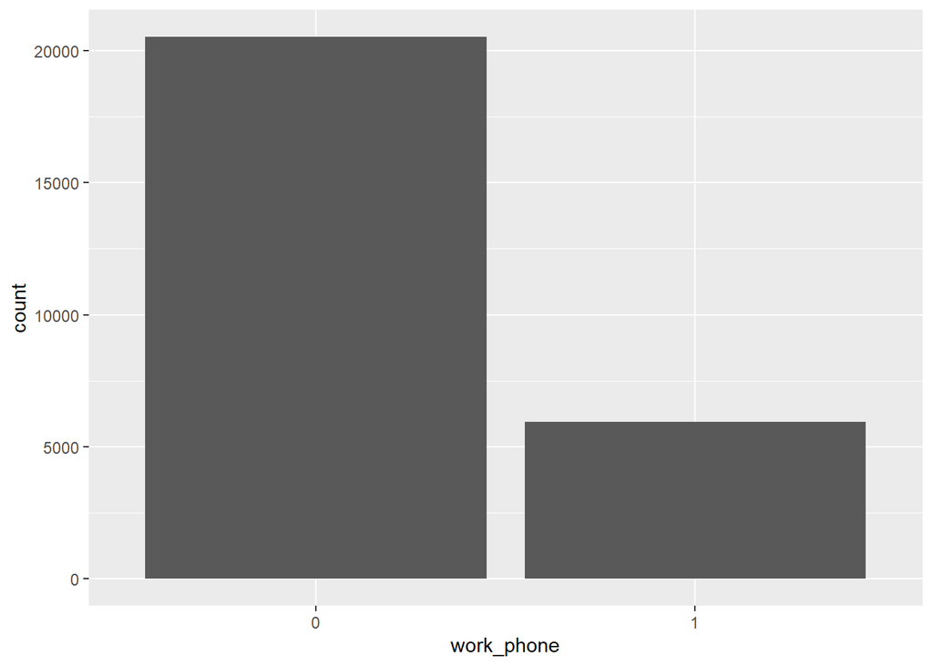

```r
#2) work_phone
ggplot(data=train)+
  geom_bar(mapping=aes(x=work_phone))
```

```r
train %>% count(work_phone)
```

```
##   work_phone     n
## 1          0 20511
## 2          1  5946
```

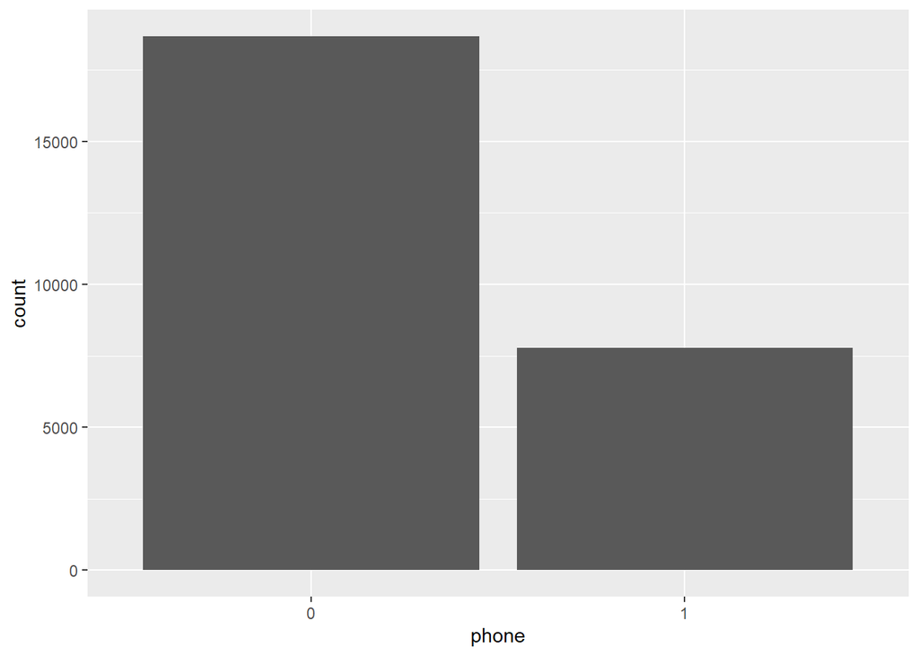

```r
#3) phone
ggplot(data=train)+
  geom_bar(mapping=aes(x=phone))
```

```r
train %>% count(phone)
```

```
##   phone     n
## 1     0 18672
## 2     1  7785
```

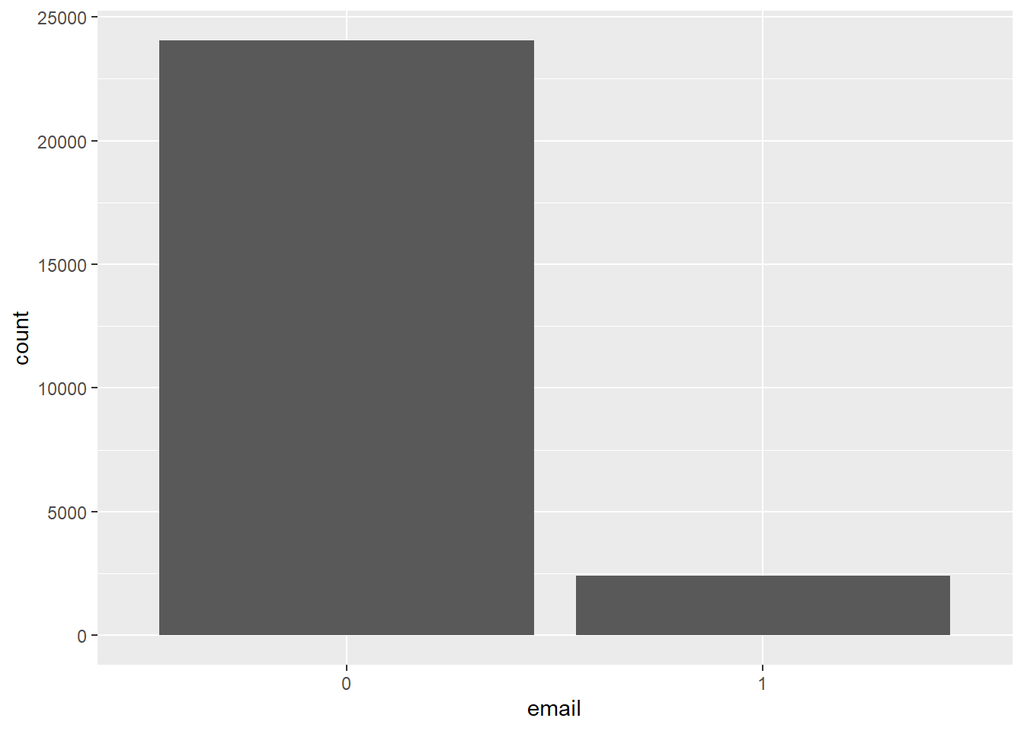

```r
#4) email
ggplot(data=train)+
  geom_bar(mapping=aes(x=email))
```

```r
train %>% count(email)
```

```
##   email     n
## 1     0 24042
## 2     1  2415
```

그래프를 보면 핸드폰은 모든 사람이 가지고 있으므로 해당 변수는 삭제해도 괜찮다고 판단됩니다. 26457명 중 업무용 전화는 5946명, 가정용 전화는 7785명이 소유하고 있으며 이메일은 2415명만이 소유하고 있다고 기록되어 있습니다. 하지만 이메일은 등록하지 않았을 확률도 있을 것 같습니다.

##이상치, 결측치

```r
table(is.na(train$FLAG_MOBIL))
```

```
##
## FALSE
## 26457
```

```r
table(is.na(train$work_phone))
```

```
##
## FALSE
## 26457
```

```r
table(is.na(train$phone))
```

```
##
## FALSE
## 26457
```

```r
table(is.na(train$email))
```

```
##
## FALSE
## 26457
```

##covariation

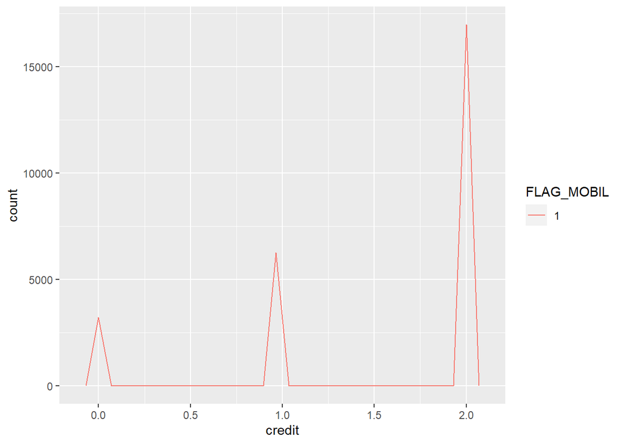

```r
ggplot(data=train, mapping=aes(x=credit))+
  geom_freqpoly(mapping=aes(color=FLAG_MOBIL))
```

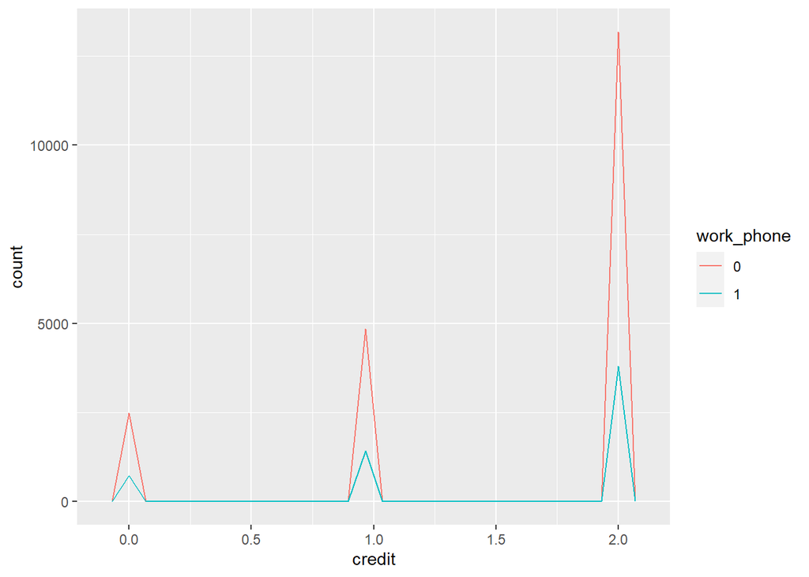

```r
ggplot(data=train, mapping=aes(x=credit))+
  geom_freqpoly(mapping=aes(color=work_phone))
```

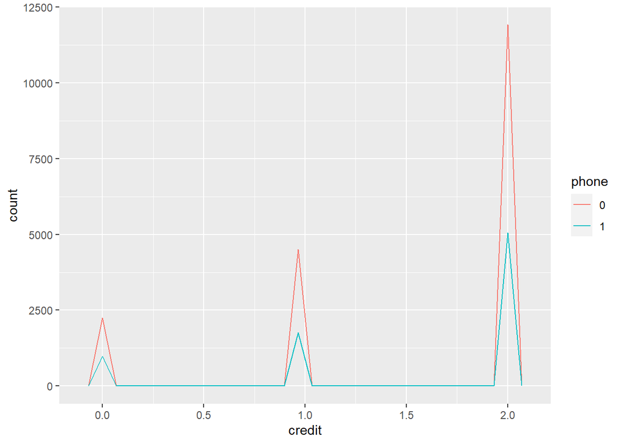

```r
ggplot(data=train, mapping=aes(x=credit))+
  geom_freqpoly(mapping=aes(color=phone))
```

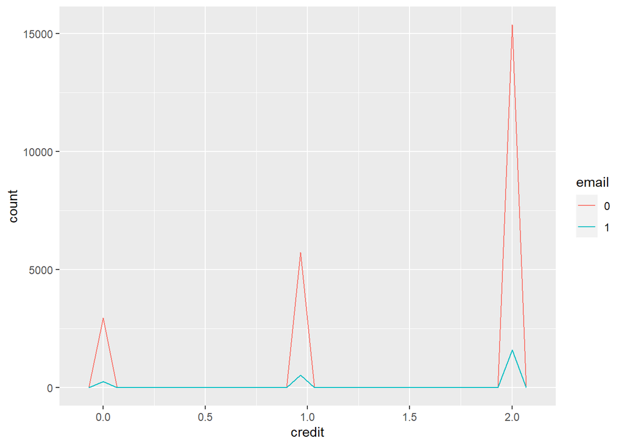

```r
ggplot(data=train, mapping=aes(x=credit))+
  geom_freqpoly(mapping=aes(color=email))
```

```r
# 굳이 소유 여부끼리 연관성은 안살펴봐도 될 것 같다.
# credit과 범주형 혹은 연속형 변수들의 관계 살펴보면 될 것 같다.
```